# Average two or more columns from a data frame

Francesco Bailo

2024-08-26

Let’s say that I have some survey data, where each row defines the responses from a single respondent. This is of course a very common way to share survey data.

Let’s also say that I have two or more continuous variables in the data **that I want to average** to create a new composite variable.

## Get some data

We first create a data frame with some random data simulating four survey responses on a value from 1 to 5 from 10 different *respondents*.

```r
survey_data <- data.frame(
  respondent_id = 1:10,  # 10 respondents
  question_1 = sample(1:5, 10, replace = TRUE),
  question_2 = sample(1:5, 10, replace = TRUE),
  question_3 = sample(1:5, 10, replace = TRUE),
  question_4 = sample(1:5, 10, replace = TRUE)
)
```

In case you are interested, let’s break down the functions we are using here:

- `data.frame()` create a data frame object in R, where each attribute `name = c(..values..)` is going to be a column.
- `1:10` Simply create a vector of numbers from 1 to 10. You can of course, use different combinations (e.g, `-1:42`)
- `sample()` with randomly sample from a vector. In this case, we pass three attributes:
  1. `1:5` define the vector (or population) from which to choose. In this case is the vector `c(1, 2, 3, 4, 5)` because we want to simulate a common situation where survey answers are given using a [Likert-type scale](https://en.wikipedia.org/wiki/Likert_scale) (e.g., 1 = Strongly disagree; 2 = Disagree; 3 = Neither agree nor disagree; 4 = Agree; 5 = Strongly agree).
  2. `10` defined how many “individuals” to sample from our “population”. In this case we decided we wanted 10 respondents and so we we will need to set a response to each question for each respondent.
  3. `replace = TRUE` means that after we sample the first value (either, 1, 2, 3, 4 or 5) we put the value back into the population so that can be re-sampled again. This is sometimes called “sampling with replacement”.

## Average columns

Now that we have some data, we can average existing variables (i.e. columns) into new variables (i.e. columns).

Let’s say I want to create a new variable as the average responses of `question_2` and `question_4`:

```r
survey_data$new_variable_1 <- # Create new variable and `<-` assign some value
  (survey_data$question_2 + survey_data$question_4) / 2 # Sum columns and divide
```

Or let’s say I want to average the responses from question 1, 3, and 4:

```r
survey_data$new_variable_2 <-
  (survey_data$question_1 + survey_data$question_3 + survey_data$question_4) / 3
```

(Note that this time we divide by 3 since we have three variables)

Let’s now see the results (note that if you replicate this you will have different numbers has `sample()` produces each time a *random* sample!)

```r
head(survey_data)
```

[output not shown]

## Issue 1: What if we have missing values?

If you have missing value in your responses, some of your composite value are also going to be missing (`NA`).

For example let’s say that the first respondent didn’t respond to question 1.

We can replace the current value of the answer with a `NA` to reflect this

```r
survey_data$question_1[1] <- NA
```

| respondent_id | question_1 | question_2 | question_3 | question_4 | new_variable_1 | new_variable_2 |
| --- | --- | --- | --- | --- | --- | --- |
| 1 | NA | 3 | 4 | 5 | 4.0 | 4.666667 |
| 2 | 4 | 5 | 2 | 4 | 4.5 | 3.333333 |
| 3 | 4 | 1 | 2 | 5 | 3.0 | 3.666667 |
| 4 | 4 | 1 | 4 | 1 | 1.0 | 3.000000 |
| 5 | 5 | 3 | 2 | 5 | 4.0 | 4.000000 |
| 6 | 2 | 2 | 3 | 1 | 1.5 | 2.000000 |
| 7 | 4 | 1 | 4 | 3 | 2.0 | 3.666667 |
| 8 | 2 | 5 | 4 | 5 | 5.0 | 3.666667 |
| 9 | 5 | 3 | 3 | 5 | 4.0 | 4.333333 |
| 10 | 5 | 1 | 3 | 4 | 2.5 | 4.000000 |

```r
survey_data$new_variable_2 <-
  (survey_data$question_1 + survey_data$question_3 + survey_data$question_4) / 3
```

| respondent_id | question_1 | question_2 | question_3 | question_4 | new_variable_1 | new_variable_2 |
| --- | --- | --- | --- | --- | --- | --- |
| 1 | NA | 3 | 4 | 5 | 4.0 | NA |
| 2 | 4 | 5 | 2 | 4 | 4.5 | 3.333333 |
| 3 | 4 | 1 | 2 | 5 | 3.0 | 3.666667 |
| 4 | 4 | 1 | 4 | 1 | 1.0 | 3.000000 |
| 5 | 5 | 3 | 2 | 5 | 4.0 | 4.000000 |
| 6 | 2 | 2 | 3 | 1 | 1.5 | 2.000000 |
| 7 | 4 | 1 | 4 | 3 | 2.0 | 3.666667 |
| 8 | 2 | 5 | 4 | 5 | 5.0 | 3.666667 |
| 9 | 5 | 3 | 3 | 5 | 4.0 | 4.333333 |
| 10 | 5 | 1 | 3 | 4 | 2.5 | 4.000000 |

You see that now also `new_variable_2` has a missing value.

Remember that R will always by default return `NA` from operations involving `NA`s.

For example,

```r
1 + 3 + NA / 3
```

```
## [1] NA
```

This is not an error but the expected behaviour.

## Issue 2: What if the scales of the responses are different?

So far we have considered responses with the same scale (1-to-5). Let’s say one of the questions implied a different scale (e.g, 1-to-10). Let’s consider a different data frame

```r
survey_data <- data.frame(
  respondent_id = 1:100,  # 100 respondents
  question_1 = sample(1:5, 100, replace = TRUE), # Note the 1-to-5 scale
  question_2 = sample(1:10, 100, replace = TRUE) # Note the 1-to-10 scale
)
```

Can we still average them all together? Well, no. That is probably not appropriate as the wider scale is going to average out the scale with the narrower scale.

- We need to rescale! How do we do it?

The easiest is probably to rescale everything to a common scale - 0 to 1 (which of course can be easily converted to a 0 to 100 scale multiplying by 100…) - before averaging.

In order to rescale a value from a known scale into a 0-to-1 scale, we can do this

```r
min_val <- 1 # Minimum value of the original scale
max_val <- 5 # Maximum value of the original scale
old_val <- 4 # Let's say for example the value to rescale is `4`

# Formula
(old_val - min_val) / (max_val - min_val)
```

Let’s rescale both variables

```r
min_val <- 1 # Minimum value of the original scale
max_val <- 5 # Maximum value of the original scale
survey_data$question_1_rescaled <-
  (survey_data$question_1 - min_val) / (max_val - min_val)
```

and

```r
min_val <- 1 # Minimum value of the original scale
max_val <- 10 # Maximum value of the original scale
survey_data$question_2_rescaled <-
  (survey_data$question_2 - min_val) / (max_val - min_val)
```

Let’s compare the distributions to see if everything is in order!

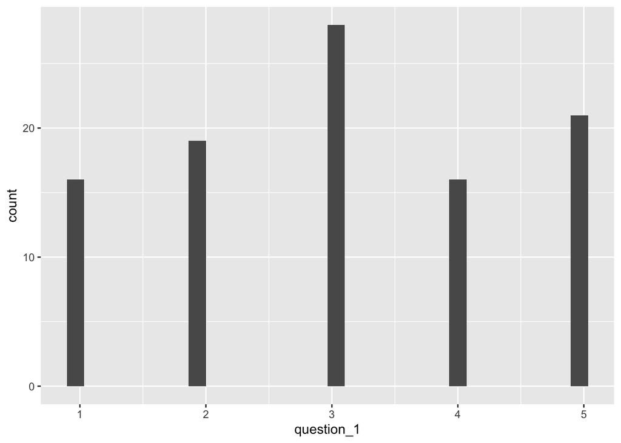

```r
ggplot(survey_data, aes(x = question_1)) +
  geom_histogram()
```

which should have the exact same distribution of

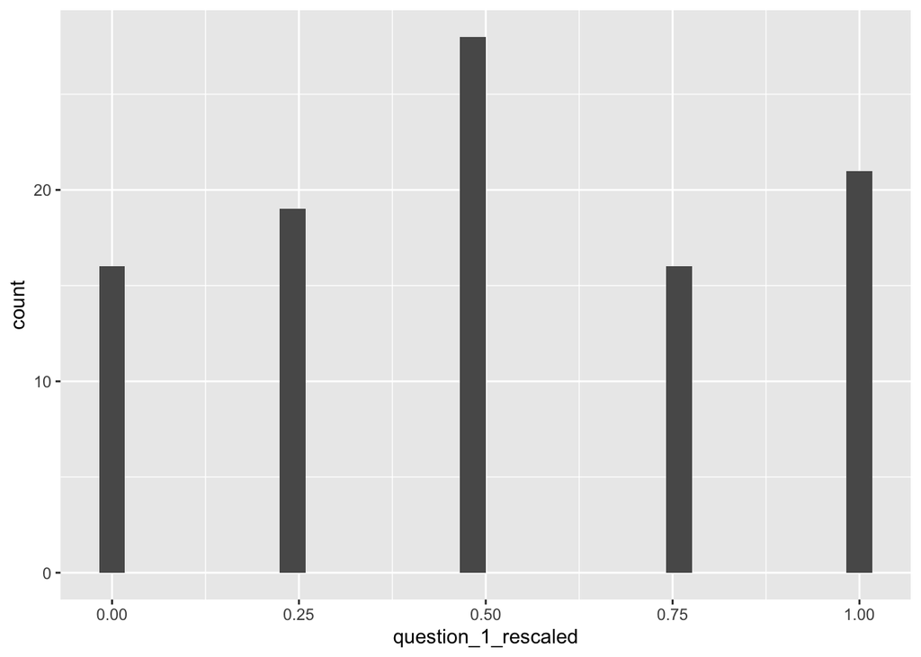

```r
ggplot(survey_data, aes(x = question_1_rescaled)) +
  geom_histogram()
```